# hw5

Chengqi

2019/9/20

# **Question 8.1**

Describe a situation or problem from your job, everyday life, current events, etc., for which a linear regression model would be appropriate. List some (up to 5) predictors that you might use.

Suppose we are in charge of a Tesla manufacture plant, we may want to predict the sales of a model of Tesla next month. In this case, linear regression model can be an appropriate to analyze how different predictors influence sales. We plan to set these predictors: the price of this model of Tesla(x1), the acceleration performance of this model(x2), the cruising range(x3), and the price level of fossil oil(x4). Each predictor do not look correlated, the data for each predictor is pretty easy to collect as well. We can build a linear regression model just like this:
$$Sales=a_0+a_1*x_1+a_2*x_2+a_3*x_3+a_4*x_4$$
Among the 4 predictors, the acceleration performance and the cruising range may have certain trends. We may need to de-trend these data in order to get better result.

# **Question 8.2**

Using crime data from http://www.statsci.org/data/general/uscrime.txt (file uscrime.txt, description at http://www.statsci.org/data/general/uscrime.html ), use regression (a useful R function is lm or glm) to predict the observed crime rate in a city with the following data: Show your model (factors used and their coefficients), the software output, and the quality of fit. Note that because there are only 47 data points and 15 predictors, you’ll probably notice some overfitting. We’ll see ways of dealing with this sort of problem later in the course.

We start with loading the data. Since it is unclear we should use which combination of predictors, the best way maybe to set all attributes as predictors to see how the model fits:

```r
data1=read.table('C:\\Users\\huangchengqi\\Desktop\\MS SCE\\19Fall\\ISYE6501\\hw5\\data 8.2\\uscrime.txt',header=TRUE)
#use the whole data set to do linear regression.
model1 <- lm(Crime~., data1)
test_data_set <-data.frame(M = 14,So = 0, Ed = 10.0, Po1 = 12.0, Po2 = 15.5,LF = 0.64, M.F = 94.0, Pop = 150, NW = 1.1, U1 = 0.12, U2 = 3.6, Wealth = 3200, Ineq = 20.1, Prob = 0.040, Time = 39.0)
pred <- predict(model1, test_data_set)
summary(model1)
```

```
##
## Call:
## lm(formula = Crime ~ ., data = data1)
##
## Residuals:
##     Min      1Q  Median      3Q     Max
## -395.74  -98.09   -6.69  112.99  512.67
##
## Coefficients:
##               Estimate Std. Error t value Pr(>|t|)
## (Intercept) -5.984e+03  1.628e+03  -3.675 0.000893 ***
## M            8.783e+01  4.171e+01   2.106 0.043443 *
## So          -3.803e+00  1.488e+02  -0.026 0.979765
## Ed           1.883e+02  6.209e+01   3.033 0.004861 **
## Po1          1.928e+02  1.061e+02   1.817 0.078892 .
## Po2         -1.094e+02  1.175e+02  -0.931 0.358830
## LF          -6.638e+02  1.470e+03  -0.452 0.654654
## M.F          1.741e+01  2.035e+01   0.855 0.398995
## Pop         -7.330e-01  1.290e+00  -0.568 0.573845
## NW           4.204e+00  6.481e+00   0.649 0.521279
## U1          -5.827e+03  4.210e+03  -1.384 0.176238
## U2           1.678e+02  8.234e+01   2.038 0.050161 .
## Wealth       9.617e-02  1.037e-01   0.928 0.360754
## Ineq         7.067e+01  2.272e+01   3.111 0.003983 **
## Prob        -4.855e+03  2.272e+03  -2.137 0.040627 *
## Time        -3.479e+00  7.165e+00  -0.486 0.630708
## ---
## Signif. codes:  0 '***' 0.001 '**' 0.01 '*' 0.05 '.' 0.1 ' ' 1
##
## Residual standard error: 209.1 on 31 degrees of freedom
## Multiple R-squared:  0.8031, Adjusted R-squared:  0.7078
## F-statistic: 8.429 on 15 and 31 DF,  p-value: 3.539e-07
```

```r
pred
```

```
##        1
## 155.4349
```

The result is so small as the former data shows number of crimes was at least 342 in a single state. So we suppose there must be some over fitting in our model. The predictors cannot be the all the attributes listed, as some of the attributes may have a certain correlation with one another. Others may be irrelevant to predict the number of crimes. First we want to see if there’s correlated predictors:

```r
#First we check the value of vif to see if some predictors are correlated.
library(car)
vif(model1)
```

```
##          M         So         Ed        Po1        Po2         LF
##   2.892448   5.342783   5.077447 104.658667 113.559262   3.712690
##        M.F        Pop         NW         U1         U2     Wealth
##   3.785934   2.536708   4.674088   6.063931   5.088880  10.530375
##       Ineq       Prob       Time
##   8.644528   2.809459   2.713785
```

```r
cor(data1[,4],data1[,5])
```

```
## [1] 0.9935865
```

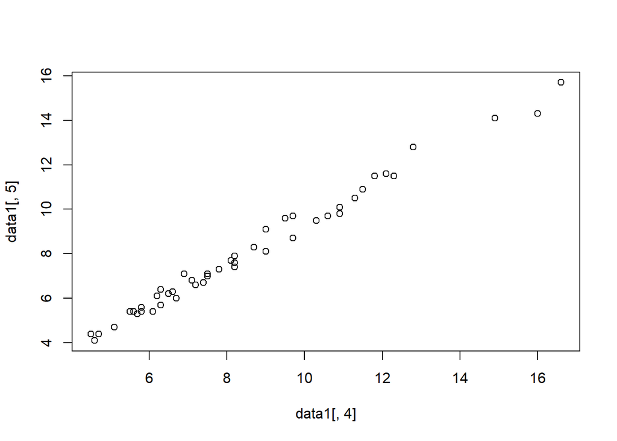

```r
plot(x=data1[,4],y=data1[,5])
```

The vif refers to variance-inflation factors. In general, if the vif value of a certain predictor is more than 10, we can say it has such correlation problem. It seems Po1 and Po2 has extremely high vif. We check the discription of the data, it shows Po1 means per capita expenditure on police protection in 1960, while Po2 means per capita expenditure on police protection in 1959. So there’s no doubt these to predictors are correlated. In order to diminish such effect, and to keep the feature of these 2 predictors, we introduce V17=(Po1+Po2)/2.

```r
data2 <- data1
data2[,17] <- (data1[,4]+data1[,5])/2
model2 <- lm( Crime ~  M + So + Ed + M.F + Pop + NW + U1 + U2+ Wealth + Ineq + Prob + Time + V17, data = data2)
test_data_set2 <-data.frame(M = 14,So = 0, Ed = 10.0,LF = 0.64, M.F = 94.0, Pop = 150,  NW = 1.1, U1 = 0.12, U2 = 3.6, Wealth = 3200, Ineq = 20.1, Prob = 0.040, Time = 39.0, V17=18.75 )
pred2<- predict(model2, test_data_set2)
summary(model2)
```

```
##
## Call:
## lm(formula = Crime ~ M + So + Ed + M.F + Pop + NW + U1 + U2 +
##     Wealth + Ineq + Prob + Time + V17, data = data2)
##
## Residuals:
##     Min      1Q  Median      3Q     Max
## -459.50 -120.35   16.45  116.50  453.35
##
## Coefficients:
##               Estimate Std. Error t value Pr(>|t|)
## (Intercept) -6.568e+03  1.523e+03  -4.314 0.000137 ***
## M            9.094e+01  4.116e+01   2.209 0.034218 *
## So           1.424e+01  1.304e+02   0.109 0.913710
## Ed           1.712e+02  5.830e+01   2.937 0.006003 **
## M.F          1.828e+01  1.703e+01   1.073 0.290882
## Pop         -7.490e-01  1.272e+00  -0.589 0.560050
## NW           1.847e+00  5.994e+00   0.308 0.759906
## U1          -5.265e+03  3.777e+03  -1.394 0.172679
## U2           1.729e+02  8.189e+01   2.111 0.042432 *
## Wealth       9.286e-02  1.025e-01   0.906 0.371515
## Ineq         7.282e+01  2.204e+01   3.304 0.002304 **
## Prob        -4.071e+03  2.194e+03  -1.856 0.072448 .
## Time        -2.627e-01  6.749e+00  -0.039 0.969180
## V17          9.981e+01  2.416e+01   4.132 0.000231 ***
## ---
## Signif. codes:  0 '***' 0.001 '**' 0.01 '*' 0.05 '.' 0.1 ' ' 1
##
## Residual standard error: 208.6 on 33 degrees of freedom
## Multiple R-squared:  0.7912, Adjusted R-squared:  0.709
## F-statistic: 9.622 on 13 and 33 DF,  p-value: 8.136e-08
```

```r
vif(model2)
```

```
##         M        So        Ed       M.F       Pop        NW        U1
##  2.828407  4.120748  4.495673  2.660389  2.479545  4.014053  4.901177
##        U2    Wealth      Ineq      Prob      Time       V17
##  5.054429 10.336935  8.173517  2.629840  2.417301  5.113057
```

Now the correlation issue seems to be ok. However, we still need to see if some of the predictors are irrelevant to predict number of crimes. We should then look at the p-value and identify irrelavent attributes.it seems So, pop, NW, wealth are irrelavant attributes because the P-value is so large. So we get rid of these predictors and try to fit the model again.

```r
model3 <- lm( Crime ~  M + Ed + M.F + U1 + U2 + Ineq + Prob + V17, data = data2)
test_data_set3 <-data.frame(M = 14, Ed = 10.0, M.F = 94.0, U1 = 0.12, U2 = 3.6, Ineq = 20.1, Prob = 0.040, V17=18.75)
pred3 <- predict(model3,test_data_set3,interval='predict',level=0.99)
summary(model3)
```

```
##
## Call:
## lm(formula = Crime ~ M + Ed + M.F + U1 + U2 + Ineq + Prob + V17,
##     data = data2)
##
## Residuals:
##     Min      1Q  Median      3Q     Max
## -475.87 -104.70    0.77  129.36  470.19
##
## Coefficients:
##             Estimate Std. Error t value Pr(>|t|)
## (Intercept) -6541.18    1210.69  -5.403 3.75e-06 ***
## M              92.58      33.92   2.729  0.00956 **
## Ed            177.75      53.50   3.323  0.00198 **
## M.F            23.83      13.75   1.733  0.09114 .
## U1          -6293.91    3375.46  -1.865  0.06997 .
## U2            192.57      73.22   2.630  0.01226 *
## Ineq           61.80      14.18   4.358 9.63e-05 ***
## Prob        -3858.65    1508.47  -2.558  0.01464 *
## V17           105.56      16.35   6.456 1.35e-07 ***
## ---
## Signif. codes:  0 '***' 0.001 '**' 0.01 '*' 0.05 '.' 0.1 ' ' 1
##
## Residual standard error: 198 on 38 degrees of freedom
## Multiple R-squared:  0.7834, Adjusted R-squared:  0.7378
## F-statistic: 17.18 on 8 and 38 DF,  p-value: 1.842e-10
```

```r
pred3
```

```
##        fit     lwr      upr
## 1 1777.847 928.533 2627.162
```

We then use stepwise method to remove predictors from model1 in order to find a model with lowest AICc.

```r
library(MuMIn)
library(MASS)
model <- lm(Crime~., data=data1)
stepAICc(model,direction='both', steps=1000)
```

```
## Start:  AIC=671.13
## Crime ~ M + So + Ed + Po1 + Po2 + LF + M.F + Pop + NW + U1 +
##     U2 + Wealth + Ineq + Prob + Time
##
##          Df Sum of Sq     RSS    AIC
## - So      1        29 1354974 512.65
## - LF      1      8917 1363862 512.96
## - Time    1     10304 1365250 513.00
## - Pop     1     14122 1369068 513.14
## - NW      1     18395 1373341 513.28
## - M.F     1     31967 1386913 513.74
## - Wealth  1     37613 1392558 513.94
## - Po2     1     37919 1392865 513.95
## <none>                1354946 514.65
## - U1      1     83722 1438668 515.47
## - Po1     1    144306 1499252 517.41
## - U2      1    181536 1536482 518.56
## - M       1    193770 1548716 518.93
## - Prob    1    199538 1554484 519.11
## - Ed      1    402117 1757063 524.86
## - Ineq    1    423031 1777977 525.42
##
## Step:  AIC=666.16
## Crime ~ M + Ed + Po1 + Po2 + LF + M.F + Pop + NW + U1 + U2 +
##     Wealth + Ineq + Prob + Time
##
##          Df Sum of Sq     RSS    AIC
## - Time    1     10341 1365315 511.01
## - LF      1     10878 1365852 511.03
## - Pop     1     14127 1369101 511.14
## - NW      1     21626 1376600 511.39
## - M.F     1     32449 1387423 511.76
## - Po2     1     37954 1392929 511.95
## - Wealth  1     39223 1394197 511.99
## <none>                1354974 512.65
## - U1      1     96420 1451395 513.88
## + So      1        29 1354946 514.65
## - Po1     1    144302 1499277 515.41
## - U2      1    189859 1544834 516.81
## - M       1    195084 1550059 516.97
```

[output cut: 118 more lines]

```
## + Wealth  1     26493 1426575 505.07
## - M.F     1    103159 1556227 505.16
## + Pop     1     16697 1436371 505.39
## + Po2     1     14148 1438919 505.47
## + So      1      9329 1443739 505.63
## + LF      1      4374 1448694 505.79
## + NW      1      3799 1449269 505.81
## + Time    1      2293 1450775 505.86
## - U1      1    127044 1580112 505.87
## - Prob    1    247978 1701046 509.34
## - U2      1    255443 1708511 509.55
## - M       1    296790 1749858 510.67
## - Ed      1    445788 1898855 514.51
## - Ineq    1    738244 2191312 521.24
## - Po1     1   1672038 3125105 537.93
```

```
##
## Call:
## lm(formula = Crime ~ M + Ed + Po1 + M.F + U1 + U2 + Ineq + Prob,
##     data = data1)
##
## Coefficients:
## (Intercept)            M           Ed          Po1          M.F
##    -6426.10        93.32       180.12       102.65        22.34
##          U1           U2         Ineq         Prob
##    -6086.63       187.35        61.33     -3796.03
```

Then we choose the model with best AICc as model4.lm(formula = Crime ~ M + Ed + Po1 + M.F + U1 + U2 + Ineq + Prob, data = data1):

```r
model4 <-lm(Crime ~ M + Ed + Po1 + M.F + U1 + U2 + Ineq + Prob, data = data1)
pred4 <- predict(model4,test_data_set,interval='predict',level=0.99)
summary(model4)
```

```
##
## Call:
## lm(formula = Crime ~ M + Ed + Po1 + M.F + U1 + U2 + Ineq + Prob,
##     data = data1)
##
## Residuals:
##     Min      1Q  Median      3Q     Max
## -444.70 -111.07    3.03  122.15  483.30
##
## Coefficients:
##             Estimate Std. Error t value Pr(>|t|)
## (Intercept) -6426.10    1194.61  -5.379 4.04e-06 ***
## M              93.32      33.50   2.786  0.00828 **
## Ed            180.12      52.75   3.414  0.00153 **
## Po1           102.65      15.52   6.613 8.26e-08 ***
## M.F            22.34      13.60   1.642  0.10874
## U1          -6086.63    3339.27  -1.823  0.07622 .
## U2            187.35      72.48   2.585  0.01371 *
## Ineq           61.33      13.96   4.394 8.63e-05 ***
## Prob        -3796.03    1490.65  -2.547  0.01505 *
## ---
## Signif. codes:  0 '***' 0.001 '**' 0.01 '*' 0.05 '.' 0.1 ' ' 1
##
## Residual standard error: 195.5 on 38 degrees of freedom
## Multiple R-squared:  0.7888, Adjusted R-squared:  0.7444
## F-statistic: 17.74 on 8 and 38 DF,  p-value: 1.159e-10
```

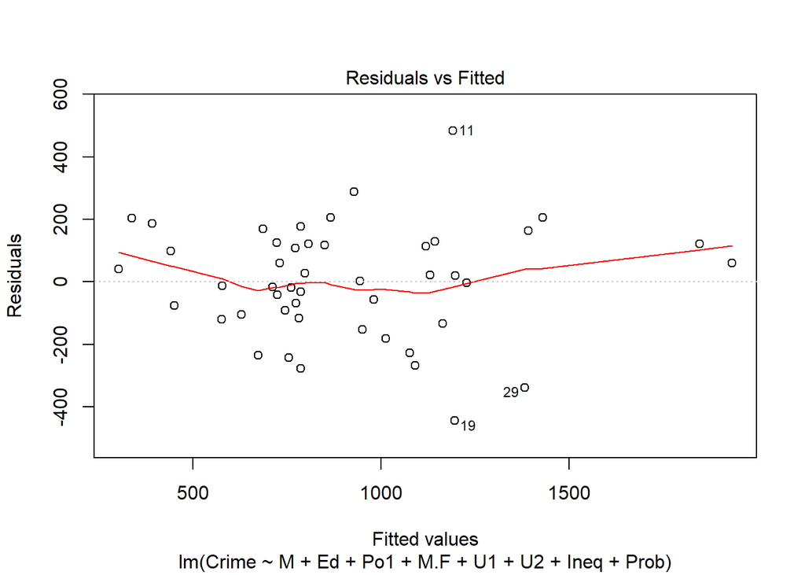

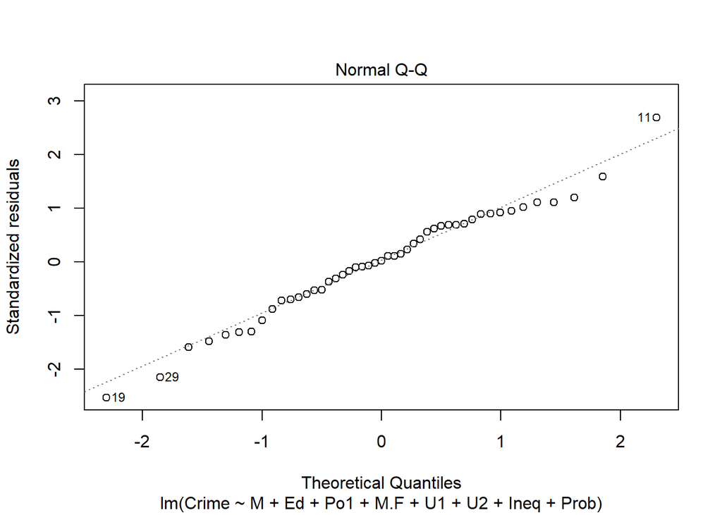

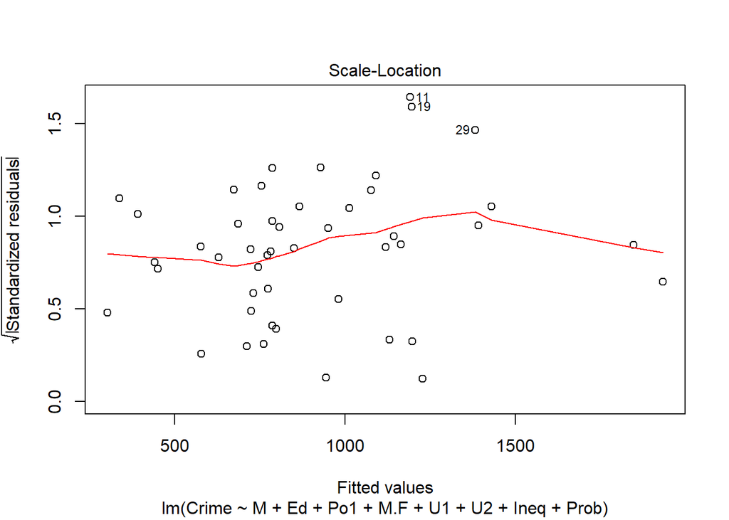

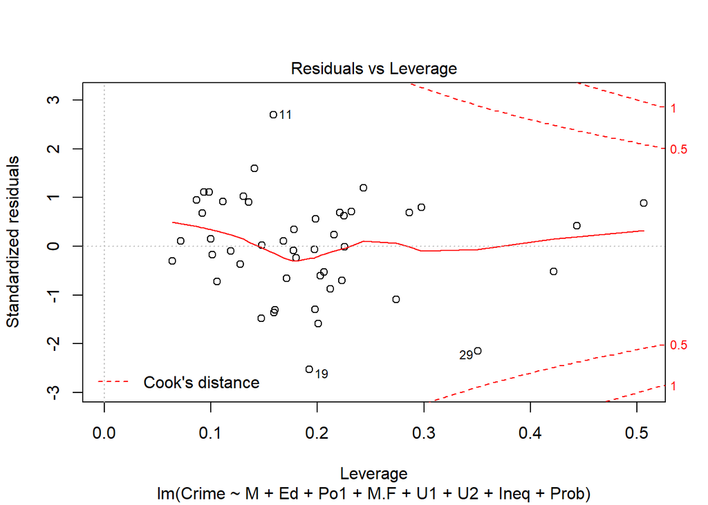

```r
plot(model4)
```

Comparing model3 and model4, we can see that Model3: Residual standard error: 198 on 38 degrees of freedom Multiple R-squared: 0.7834, Adjusted R-squared: 0.7378 F-statistic: 17.18 on 8 and 38 DF, p-value: 1.842e-10 Model4: Residual standard error: 195.5 on 38 degrees of freedom Multiple R-squared: 0.7888, Adjusted R-squared: 0.7444 F-statistic: 17.74 on 8 and 38 DF, p-value: 1.159e-10 Comparing the adjusted R-squred and F-statistic values, model4 is more likely to be a better model. The Chosen model is: Crime=-6426.10+93.32M+180.12Ed+102.65Po1+22.34M.F-6086.631U1+187.35U2+61.33Ineq-3796.03Prob

The predictive value is 1038.

```r
pred4
```

```
##        fit      lwr      upr
## 1 1038.413 376.4115 1700.415
```